# Pipeline reproducible con Nextflow, PySpark y Bash

Trabajo Unidad 2 — Técnicas Avanzadas de Programación

Autor/a

Neyling Yuriko Teresa Macalopú Rimachi

Fecha de entrega

20 de julio de 2026

## 1 Resumen

El presente informe presenta la construcción de un pipeline reproducible en Nextflow que integra el análisis de secuencias biológicas, procesos externos adaptados desde un repositorio de terceros, y un reporte final.

El objetivo no fue obtener nuevos resultados biológicos, sino **transformar un análisis exploratorio de notebook en un flujo automatizado, parametrizado y verificable por terceros**. Los hallazgos más relevantes son de naturaleza metodológica: el escalamiento con Spark fue sublineal en esta carga de trabajo; el gráfico de recurrencia no mostró evidencia descriptiva de estructura por encima del modelo nulo considerado; y la CNN inicial no llegó a aprender y predecía siempre la misma clase, que se corrigió mediante cambios simultáneos en la arquitectura, la ponderación de clases, la tasa de aprendizaje y la codificación de entrada.

La corrida analizada en este informe corresponde al commit `9b063a0 (árbol limpio)`, ejecutada el 2026-07-19T23:12:31 sobre 16 CPUs lógicas.

## 2 Introducción y objetivos

El trabajo integra reproducibilidad computacional, control de versiones, descarga automática de datos públicos, procesamiento distribuido y automatización con Bash. El pipeline debe poder ser clonado, ejecutado y revisado por terceros sin intervención manual.

Los objetivos son

1. **Proceso 1** — automatizar el análisis del Problema 1 con PySpark, partiendo de la descarga de los datos desde Figshare.
2. **Proceso 2** — integrar y **adaptar** los procesos `calculoBashTask` y `generaReporteTask` de un repositorio externo.
3. **Proceso 3** — generar un reporte final propio.

## 3 Metodología

### 3.1 Arquitectura del pipeline

El pipeline se compone de cinco procesos de Nextflow. La topología no es lineal, es decir, tras la descarga, el análisis PySpark y el cálculo Bash se ejecutan **en paralelo**, y de eso dependen los dos reportes.

```
DOWNLOAD_FIGSHARE
   ├──> RUN_PROBLEM1_PYSPARK ──┐
   └──> CALCULO_BASH ──┬───────┴──> FINAL_REPORT
                       └──> GENERA_REPORTE
```

El diagrama se lee siguiendo las flechas. `DOWNLOAD_FIGSHARE` no depende de nada y por eso abre el flujo, es decir, descarga y verifica los archivos. De ahí salen **dos ramas independientes**, y esa bifurcación es uno de los puntos importantes; `RUN_PROBLEM1_PYSPARK` y `CALCULO_BASH` necesitan los mismos FASTA pero no se necesitan entre sí, de modo que Nextflow los ejecuta al mismo tiempo. Después, más abajo en el esquema, las dos flechas que llegan a `FINAL_REPORT` reflejan que el Proceso 3 se genera a partir de los resultados de ambas ramas, las tablas de PySpark y el CSV del cálculo Bash. `GENERA_REPORTE` sale de `CALCULO_BASH`, porque solo resume esa búsqueda.

La estructura es una decisión de diseño, al declarar únicamente las dependencias de datos reales, Nextflow paraleliza lo que puede paralelizarse. El grafo generado automáticamente está en `Results/pipeline_dag.html`.

### 3.2 Datos

Los datos provienen de un registro público de Figshare (DOI 10.6084/m9.figshare.32968955 licencia CC BY 4.0) con 7 archivos FASTA que suman aproximadamente 3.4 GB. El pipeline descarga **solo los dos archivos que el análisis necesita** (122 MB aproximadamente) controlado por el parámetro `--download_all`.

El genoma de referencia (`Genoma_referencia.fasta`) tiene **2 982 397 bases**. Del archivo de consulta (`Secuenciacion4_correctedshortReads.fasta`) se leen 20 reads.

La integridad se verifica contra el `supplied_md5` que publica la API de Figshare, si el hash no coincide, el pipeline se detiene.

## 4 Resultados

### 4.1 Búsqueda mediante expresiones regulares

Se evaluaron **360 patrones** (20 reads × 6 largos × 3 formas de extracción) con un total de **912 469 calces**.

| Largo del patrón | Calces promedio |
| --- | --- |
| 4 | 15 111.9 |
| 8 | 94.7 |
| 12 | 1.0 |
| 16 | 0.1 |
| 24 | 0.1 |
| 32 | 0.0 |

El número de calces cae de forma aproximadamente exponencial con el largo del patrón, que es lo que predice la teoría, si las cuatro bases fueran equiprobables, la frecuencia esperada de un patrón de largo $L$ en un genoma de $G$ bases es $G/4^L$. Cada base adicional divide entre cuatro las apariciones esperadas. Con largos de 16 o más, los calces prácticamente desaparecen, de modo que a partir de ese umbral una subsecuencia presenta una probabilidad reducida de coincidencia aleatoria bajo el modelo nulo.

Un detalle de implementación con consecuencias, se usa *lookahead* `(?=(...))` para contar **ocurrencias solapadas**. Sin esto, la expresión regular avanza más allá de cada calce y subestima el conteo en patrones repetitivos.

**NotaSobre las posiciones registradas**

`regex_matches.csv` guarda las **primeras 10 posiciones** de cada patrón; el conteo completo está en `match_count`. Registrar todas las posiciones haría que el archivo no sea manejable sin aportar información adicional.

### 4.2 Paralelización con PySpark

| Particiones | Tiempo medio (s) | Desv. est. (s) | Speedup | Eficiencia | Calces totales |
| --- | --- | --- | --- | --- | --- |
| 1 | 9.025 | 0.009 | 1.00x | 100% | 912469 |
| 2 | 4.712 | 0.026 | 1.92x | 96% | 912469 |
| 4 | 2.508 | 0.008 | 3.60x | 90% | 912469 |
| 8 | 1.628 | 0.046 | 5.54x | 69% | 912469 |
| 16 | 1.347 | 0.071 | 6.70x | 42% | 912469 |

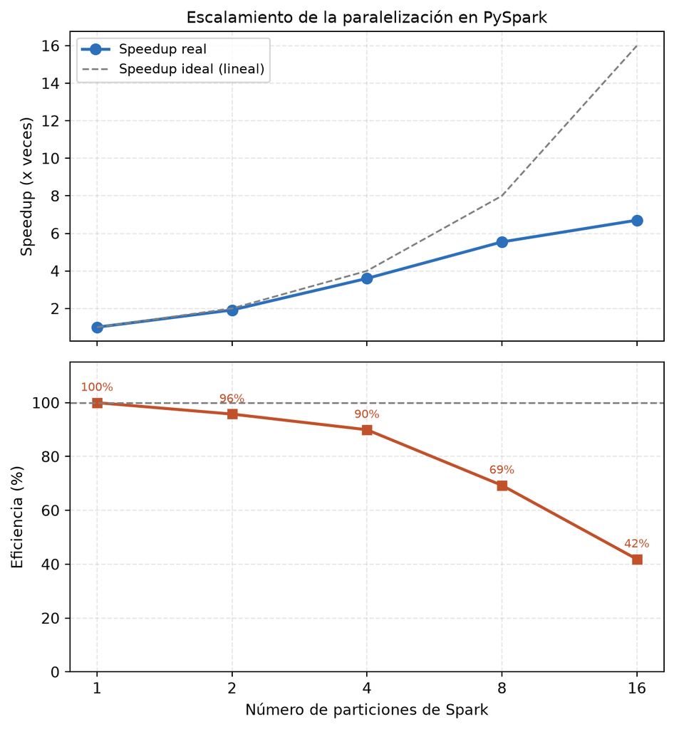

Figura 1: Arriba, speedup real frente al ideal. Abajo, eficiencia por partición.

La Figura 1 muestra lo que la tabla indica. La curva azul es el speedup real y la línea gris punteada, el speedup ideal sería, si Spark escalara perfectamente, ambas coincidirían. Sin embargo, no lo hacen, y la separación entre ellas crece con cada partición añadida. La curva naranja mide esa misma pérdida desde otro ángulo (cuánto rinde en promedio cada partición) y desciende de forma sostenida; en este sentido, las dos trayectorias quieren dar a conocer lo mismo.

El mejor speedup es **6.70x** con 16 particiones, sobre 16 CPUs lógicas. Pero el número que importa es la **eficiencia**: con 16 particiones cada una rinde apenas el **42%** de lo que rendiría en un escalamiento perfecto.

La brecha entre la curva real y la ideal es el costo de coordinación, es decir, serializar las tareas, repartirlas entre los ejecutores y recolectar los resultados. Ese costo es fijo por partición, mientras que el trabajo útil por partición disminuye a medida que se divide más. Se concluye que en la práctica **Spark no acelera automáticamente, sino que hace que acelere mientras el trabajo por partición supere el costo de coordinarla.**

La desviación estándar pasa de 0.009 s con 1 partición a 0.071 s con 16. Es decir, aumenta. Esa dispersión creciente es la firma de la saturación: con muchas particiones compitiendo por los mismos núcleos, el tiempo pasa a depender de la contención.

**Prueba de correctitud.** El total de calces es **912 469** e **idéntico en las 5 configuraciones**. Es la verificación que hace interpretable todo lo anterior la paralelización cambió el tiempo no el resultado. Un speedup sobre resultados distintos no sería una mejora de rendimiento sino un error de correctitud.

### 4.3 Gráficos de recurrencia

Se generó un gráfico de recurrencia para evaluar autosimilaridad dentro de una secuencia y similitud entre la secuencia de consulta y la de referencia (`Results/Problem1/Figures/recurrence_plot.png`).

Las densidades medidas fueron **0.2583** en autosimilaridad y **0.2476** en el caso cruzado, frente a **0.2500** esperado bajo un modelo nulo de bases independientes y equiprobables (con cuatro bases, dos posiciones cualquiera coinciden una de cada cuatro veces).

La matriz de autosimilaridad **incluye la diagonal principal**, donde cada posición coincide consigo misma por construcción y eleva artificialmente la densidad. Descontándola sobre las 500 bases evaluadas, la densidad baja a **0.2568**, aún más cerca del valor teórico.

Las desviaciones respecto del modelo nulo son pequeñas (0.0068 y 0.0024), lo que es **consistente con la ausencia de estructura detectable** a esta escala. Cabe mencionar que se trata de una observación descriptiva y no de un resultado nulo demostrado, es otras palabras, no se calculó una distribución nula por permutaciones, ni un intervalo de confianza, tampoco se aplicó una prueba estadística. Establecerlo de manera fija exigiría comparar contra secuencias simuladas.

La figura muestra un patrón de textura que a simple vista sugiere estructura biológica. La medición no respalda esa lectura, y ese contraste es lo instructivo, es decir, un gráfico convincente no sustituye a una cuantificación, y sin la línea base no habría forma de saber qué se está mirando.

### 4.4 Codificación 8-bit y convoluciones 1D

La codificación usa k-meros de largo 4 sobre el alfabeto `{A, C, G, T}`, lo que produce $4^4 = 256$ valores distintos, exactamente el rango de un entero sin signo de 8 bits (`uint8`, 0–255). La correspondencia es la razón por la que el enunciado sugiere ese largo.

Sobre esa señal se aplicaron convoluciones 1D, cuya serie de tiempo resultante está en `Results/Problem1/conv1d_timeseries.csv` y su visualización en `Results/Problem1/Figures/conv1d_signal.png`.

Un cambio necesario durante el desarrollo fue **unificar el diccionario de bases**. Existían dos mapeos distintos en partes distintas del código, lo que producía codificaciones incompatibles entre sí. Ahora hay un único `BASE_MAP = {"A": 0, "C": 1, "G": 2, "T": 3}`.

### 4.5 Búsqueda jerárquica con CNN 1D

| Métrica | Valor |
| --- | --- |
| Línea base (clase mayoritaria) | 0.6780 |
| Accuracy | **0.9520** |
| F1 clase mayoritaria (clase 1, n=678) | 0.9640 |
| F1 clase minoritaria (clase 0, n=322) | **0.9279** |
| Macro-F1 | 0.9460 |
| Clases distintas predichas | 2 |
| Épocas | 300 |
| Peso aplicado a la clase 1 | 0.451 |

|  | Predicho 0 | Predicho 1 |
| --- | --- | --- |
| **Real 0** | 309 | 13 |
| **Real 1** | 35 | 643 |

El modelo alcanza un accuracy de **0.9520** frente a una línea base de 0.6780 (la proporción de la clase mayoritaria), y predice 2 clases distintas. Con clases desbalanceadas el accuracy debe complementarse con métricas por clase, en este caso, el **F1 de la clase minoritaria (clase 0) es 0.9279** y el **Macro-F1, 0.9460**. En este conjunto la clase mayoritaria es la **clase 1**, con 67.8% de las muestras del conjunto de prueba.

#### 4.5.1 El diagnóstico que hizo falta y correcciones

La primera versión alcanzó un accuracy de 0.7440 y parecía razonable. Sin embargo, 0.7440 era **exactamente** la proporción de la clase mayoritaria. El modelo predecía la misma clase para todas las muestras.

La aritmética lo confirmó sin ambigüedad, con 3811 ejemplos de la clase 0, $0.7667 \times 4000 = 3067$ en entrenamiento más $0.7440 \times 1000 = 744$ en prueba dan exactamente 3811. Además, el accuracy quedaba congelado desde la época 20 hasta la 199 — el desempeño de la red permaneció estancado y convergió hacia la predicción constante de la clase mayoritaria.

Causas:

1. **Desbalance de clases (76% / 24%).** Ante una función de pérdida sin ponderar, predecir siempre la clase mayoritaria es un óptimo local cómodo.
2. **Uso de `AdaptiveMaxPool1d` poco adecuado para una tarea dependiente de frecuencias.** La etiqueta depende del **conteo** de bases G/C en la ventana, y el max-pooling conserva únicamente la activación máxima, **descartando el conteo**. Es decir, el max-pooling probablemente dificultaba el aprendizaje de una etiqueta que depende de frecuencias, porque la agregación por máximos puede perder información sobre el número de activaciones.

Las correcciones aplicadas fueron: `AdaptiveAvgPool1d` en lugar de `AdaptiveMaxPool1d` (el promedio sí preserva la información de conteo), pesos de clase en `CrossEntropyLoss`, tasa de aprendizaje de 1e-3 a 1e-2, y **codificación one-hot de 4 canales** en reemplazo de enteros 0–3, codificar las bases como una escala numérica le sugiere a la red que T está “más lejos” de A que C, lo cual es biológicamente falso.

Los cuatro cambios se aplicaron **de forma simultánea**, de modo que no se puede atribuir la mejora a una sola de las modificaciones; para eso haría falta un estudio de ablación, con el fin de aislar una por una.

Además es importante señalar que las cifras del diagnóstico (3811 ejemplos de la clase 0, línea base 0.7440) corresponden a la **versión inicial**, generada con una configuración de muestreo distinta. En la corrida final el conjunto se regeneró y el balance de clases cambió, la clase mayoritaria pasó a ser la clase 1. Por eso la línea base y las proporciones difieren entre ambos momentos, y no se trata de resultados mezclados sino de dos conjuntos distintos.

El peso registrado en `cnn_results.csv` bajo el nombre `minority_weight` corresponde en realidad al **peso aplicado a la clase 1**; al ser esta la clase mayoritaria, un valor menor que 1 reduce la contribución de sus errores a la función de pérdida, compensando su mayor frecuencia en el conjunto de entrenamiento.

### 4.6 Proceso 2: integración de procesos externos

El proceso `calculoBashTask` adaptado localizó **4 de 20 reads** usando una semilla de 16 bases, con un tiempo medio de 28.4 ms por búsqueda.

**Por qué una semilla y no el read completo.** Buscar el read entero no encontraba nada: 0 de 20. Porque un read real difiere de la referencia por errores de secuenciación y puede provenir de la hebra complementaria. Los alineadores reales resuelven esto igual, buscan una **semilla** corta y extienden desde ahí.

**Justificación del uso de las 16 bases.** El largo se eligió por especificidad, no por tanteo. Bajo un modelo nulo de bases independientes y equiprobables, las apariciones esperadas de un patrón de largo $L$ son $G/4^L$; con $G = 2,982,397$ bases y $L = 16$, eso da **0.0007** ocurrencias esperadas. Esto indica una alta especificidad teórica, aunque no demuestra por sí solo que toda coincidencia observada sea biológicamente verdadera, en sí, los genomas contienen repeticiones, composición desigual de bases y regiones de baja complejidad que el modelo nulo no recoge. El valor es parametrizable con `--semilla`.

### 4.7 Proceso 3: comparación entre herramientas

| Métrica | PySpark | Bash + awk |
| --- | --- | --- |
| Búsquedas realizadas | 360 | 20 |
| Tiempo por búsqueda | **6.97 ms** | **28.40 ms** |
| Ocurrencias contadas | todas (solapadas) | solo la primera |
| Paralelismo | 4 particiones | secuencial |

Las dos herramientas **no ejecutan la misma carga**: PySpark evalúa 360 patrones de largo variable contando todas las ocurrencias solapadas, mientras Bash busca 20 reads por una semilla fija y se detiene en la primera coincidencia.

En las configuraciones evaluadas, el cociente entre los tiempos medios por búsqueda fue de aproximadamente **4.1**. No obstante, ese valor **no constituye una comparación controlada de rendimiento**: ambas herramientas ejecutan operaciones distintas y el cálculo no incorpora de forma equivalente los costos de inicialización, en particular el arranque de la JVM y del contexto de Spark. Determinar a partir de qué volumen conviene una u otra exigiría medir ambas sobre exactamente la misma tarea y varios tamaños de entrada.

El reporte del Proceso 3 (`Reports/final_report.html`) y su figura (`Results/Figures/final_summary_plot.png`) se generan automáticamente en cada corrida y son distintos del reporte del Proceso 2, que resume únicamente la búsqueda Bash.

## 5 Reproducibilidad

Las decisiones que sostienen la reproducibilidad del pipeline:

**Semilla aleatoria fija.** Sin ella cada ejecución daría números distintos, que en un trabajo sobre reproducibilidad este sería un problema.

**Verificación MD5 contra Figshare.** El pipeline compara el hash de lo descargado contra el `supplied_md5` de la API y se detiene si difiere.

**Cero rutas absolutas.** Los scripts se pasan mediante `Channel.fromPath("${projectDir}/scripts/...")`.

**Auto-registro del entorno.** `run_parameters.csv` captura 26 parámetros en cada corrida, incluidas todas las versiones y el commit de git.

| Componente | Versión |
| --- | --- |
| Sistema | Linux-6.18.33.1-microsoft-standard-WSL2-x86_64-with-glibc2.43 |
| Python | 3.14.4 |
| Java | 17.0.19 |
| Spark/PySpark | 4.1.2 / 4.1.2 |
| PyTorch | 2.13.0+cpu |
| Semilla | 42 |
| Commit | 9b063a0 (árbol limpio) |

**ImportanteProblema de reproducibilidad**

El registro del estado de git marcaba el árbol como “sucio” aunque el código estuviera confirmado. La causa era doble. Primero, el chequeo incluía `Results/`, que **genera el propio pipeline**: el árbol se ensuciaba solo. Y al excluir esa carpeta con `:!Results` el problema persistía, porque el proceso se ejecuta dentro del `work/` de Nextflow y **git interpreta los pathspec relativos al directorio actual**, no a la raíz del repositorio. La solución fue `:(top,exclude)`, que los ancla a la raíz.

La pregunta que el parámetro debe responder es “¿estaba el **código** versionado cuando esto se ejecutó?”.

## 6 Limitaciones

**El benchmark mide una máquina compartida.** Los tiempos varían alrededor de un 10% entre corridas porque el sistema operativo compite por los mismos núcleos. Por eso se promedian tres repeticiones y se reporta la desviación estándar.

**El análisis usa un subconjunto de los datos.** Se leen 20 reads de los 725 228 disponibles. Esto permitió demostrar el flujo automatizado pero no permite conclusiones biológicas sobre la muestra.

**La comparación PySpark / Bash no es una comparación controlada.** Como se detalló, las cargas difieren en cantidad, algoritmo y criterio de conteo.

**La ruta de instalación con conda no fue ejecutada.** El `environment.yml` replica las versiones verificadas, pero el entorno que se probó es el de `venv` descrito en `env/requirements.txt`.

**La búsqueda Bash no es un alineador completo.** El proceso Bash implementa una búsqueda exacta de semillas, pero no un alineamiento con extensión, tolerancia a errores ni evaluación de la hebra reverso-complementaria. La analogía con los alineadores reales se refiere solo a la estrategia de sembrado, no a sus capacidades completas.

## 7 Conclusiones

**Sobre la paralelización.** Spark no es un acelerador automático. En esta carga el speedup se queda muy por debajo del lineal y la eficiencia por partición cae drásticamente al aumentar el paralelismo. Paralelizar tiene un costo, y ese costo solo se justifica cuando el trabajo por partición lo supera. El hecho de que el número de calces se mantenga idéntico en todas las configuraciones es lo que permite afirmar que la diferencia observada es de rendimiento y no de corrección.

**Sobre la validación de resultados.** Dos de los hallazgos del trabajo fueron errores detectados por contraste con una línea base, la CNN que funcionaba con un accuracy igual al de la clase mayoritaria, y el gráfico de recurrencia que sugería visualmente una estructura cuya densidad, al cuantificarse, resultó próxima a la esperada bajo el modelo nulo considerado. En ambos casos el resultado parecía correcto hasta que se comparó con lo que ocurriría sin modelo y sin señal. La línea base no fue un requisito, sino el criterio que permitió distinguir un resultado significativo de un comportamiento aparente.

**Sobre la arquitectura de modelos.** El desempeño inicial de la CNN fue compatible con una arquitectura poco adecuada para una tarea propia de conteos. La sustitución de `AdaptiveMaxPool1d` por `AdaptiveAvgPool1d` formó parte de un conjunto de cuatro cambios aplicados simultáneamente; por ello no puede atribuirse causalmente la mejora a una sola modificación sin un estudio de ablación.

**Sobre la reproducibilidad.** La automatización debe registrar de manera verificable su propio estado de ejecución. Un pipeline que termina con `Succeeded: 5` puede haber publicado sus resultados en una carpeta llamada `null`, y un registro del estado de git puede marcar el árbol de trabajo como “sucio” por inspeccionar el directorio que él mismo produce; de este modo,la reproducibilidad siempre debe ser verificada y no solo declarada.

## 8 Referencias y atribución del código externo

El Proceso 2 adapta los procesos `calculoBashTask` y `generaReporteTask` del repositorio externo indicado en la guía del curso:

- **Autor:** David A. Castro S.
- **Repositorio:** `tap_pipeline_gen`
- **Enlace:** https://github.com/DavidCastroSalinas/tap_pipeline_gen
- **Consultado en:** julio de 2026
- **Licencia:** el repositorio no declara un archivo de licencia explícito. Su uso en este trabajo corresponde a la adaptación con fines académicos.

Las adaptaciones realizadas sobre ese código, búsqueda, reimplementación de `generaReporteTask` de R a Python, eliminación de rutas absolutas y correcciones de compatibilidad, se detallan en el README del proyecto (sección 6) y en la sección 4.6 de este informe.

## 9 Declaración de uso de inteligencia artificial

Este trabajo se desarrolló con apoyo de Claude (Anthropic) en la depuración de errores de Nextflow, Bash, Spark y Git, revisión de redacción y contraste de resultados intermedios. Por otra parte, el análisis del Problema 1, la publicacióndel conjunto de datos en Figshare, la creación y gestión del repositorio en GitHub, la construcción del pipeline en Nextflow, la adaptación de los procesos externos y la ejecución de todos los experimentos son de elaboración propia.